# STOR 455 Homework 2

#### MODEL #3: Again use Age as a predictor for Price, but now for new data

17. Select a new sample from the UsedCar dataset using the same *Model* car that was used in the previous sections, but now from cars for sale in North Carolina. You can mimic the code used above to select this new sample.

```r
library(readr)

# This line will only run if the UsedCars.csv is stored in the same directory as this notebook!
UsedCars2 <- read_csv("UsedCars.csv")
# Delete the ** below and enter the two letter abbreviation for the state of your choice.
StateOfMyChoice2 = "NC"

# Creates a dataframe with the number of each model for sale in your state
Cars2 = as.data.frame(table(UsedCars2$Model[UsedCars2$State==StateOfMyChoice2]))

# Renames the variables
names(Cars2)[1] = "Model"
names(Cars2)[2] = "Count"

# Restricts the data to only models with at least 100 for sale
# Before submitting, comment this out so that it doesn't print while knitting
# Enough_Cars = subset(Cars, Count>=100)
# Enough_Cars
```

```r
# Delete the ** below and enter the model that you chose from the Enough_Cars data.
ModelOfMyChoice2 = "Accord"

# Takes a subset of your model car from your state
MyCars2 = subset(UsedCars2, Model==ModelOfMyChoice2 & State==StateOfMyChoice2)

# Check to make sure that the cars span at least 5 years.
range(MyCars2$Year)
```

```
[1] 1997 2017
```

```r
# Add a new variable for the age of the cars.
MyCars2$Age = 2017 - MyCars2$Year
```

18. Calculate the least squares regression line that best fits your new data and produce a scatterplot of the relationship with the regression line on it.

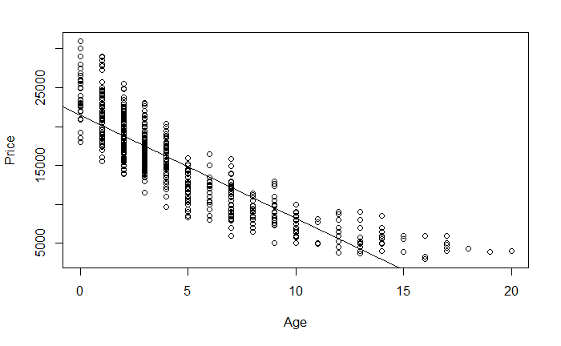

```r
modnc <- lm(Price~Age, MyCars2)
plot(Price~Age, MyCars2)
abline(modnc)
```

```r
summary(lm(Price~Age, MyCars2))
```

```
Call:
lm(formula = Price ~ Age, data = MyCars2)

Residuals:
    Min      1Q  Median      3Q     Max
-6494.8 -1849.0  -297.4  1552.1  9575.5

Coefficients:
            Estimate Std. Error t value Pr(>|t|)
(Intercept) 21419.54     148.52  144.22   <2e-16 ***
Age         -1324.95      27.17  -48.76   <2e-16 ***
---
Signif. codes:  0 ‘***’ 0.001 ‘**’ 0.01 ‘*’ 0.05 ‘.’ 0.1 ‘ ’ 1

Residual standard error: 2720 on 774 degrees of freedom
Multiple R-squared:  0.7544,    Adjusted R-squared:  0.7541
F-statistic:  2378 on 1 and 774 DF,  p-value: < 2.2e-16
```

19. How does the relationship between *Price* and *Age* for this new data compare to the regression model constructed in the first section? Does it appear that the relationship between *Age* and *Price* for your *Model* of car is similar or different for the data from your two states? Explain.

The correlation between price, mileage and age are still fairly similar between states. The only notable difference would be that NC has slightly lower correlation rates between mileage and age. Texas’s correlation rates are 0.84 between mileage and age, while NC’s correlation rates are 0.82 between age and mileage.

When running a cor.test for the slope of the two variables still have very similar correlations, and both have very low pvalues - which suggest that we have evidence that suggests we can reject the null hypothesis that the true correlation is equal to zero.

Lastly, looking at teh residual plot of the linear regression models for TX and NC, this shows us that TX has a stronger right skew than NC. NC’s model, while also right skewed, is signifigantly less skewed than TX’s model.

Overall, I would say that the relationship between age and price for the Honda Accord in both TX and NC are similar based on the reasons above.

```r
#TX
cor(MyCars[c(2,4,10)])
```

```
             Price    Mileage        Age
Price    1.0000000 -0.8556332 -0.8661308
Mileage -0.8556332  1.0000000  0.8494867
Age     -0.8661308  0.8494867  1.0000000
```

```r
#NC
cor(MyCars2[c(2,4,10)])
```

```
             Price    Mileage        Age
Price    1.0000000 -0.8458657 -0.8685637
Mileage -0.8458657  1.0000000  0.8221806
Age     -0.8685637  0.8221806  1.0000000
```

```r
#TX
cor.test(MyCars$Price, MyCars$Age)
```

```
    Pearson's product-moment correlation

data:  MyCars$Price and MyCars$Age
t = -64.257, df = 1375, p-value < 2.2e-16
alternative hypothesis: true correlation is not equal to 0
95 percent confidence interval:
 -0.8787504 -0.8523011
sample estimates:
       cor
-0.8661308
```

```r
#NC
cor.test(MyCars2$Price, MyCars2$Age)
```

```
    Pearson's product-moment correlation

data:  MyCars2$Price and MyCars2$Age
t = -48.76, df = 774, p-value < 2.2e-16
alternative hypothesis: true correlation is not equal to 0
95 percent confidence interval:
 -0.8848527 -0.8501536
sample estimates:
       cor
-0.8685637
```

```r
anova(mod1)
```

```
Analysis of Variance Table

Response: Price
            Df     Sum Sq    Mean Sq F value    Pr(>F)
Age          1 3.2743e+10 3.2743e+10    4129 < 2.2e-16 ***
Residuals 1375 1.0904e+10 7.9300e+06
---
Signif. codes:  0 ‘***’ 0.001 ‘**’ 0.01 ‘*’ 0.05 ‘.’ 0.1 ‘ ’ 1
```

```r
anova(modnc)
```

```
Analysis of Variance Table

Response: Price
           Df     Sum Sq    Mean Sq F value    Pr(>F)
Age         1 1.7588e+10 1.7588e+10  2377.5 < 2.2e-16 ***
Residuals 774 5.7259e+09 7.3978e+06
---
Signif. codes:  0 ‘***’ 0.001 ‘**’ 0.01 ‘*’ 0.05 ‘.’ 0.1 ‘ ’ 1
```

```r
summary(mod1)
```

```
Call:
lm(formula = Price ~ Age, data = MyCars)

Residuals:
    Min      1Q  Median      3Q     Max
-7533.1 -1820.8  -376.3  1423.6 15619.3

Coefficients:
            Estimate Std. Error t value Pr(>|t|)
(Intercept) 21571.35     114.33  188.68   <2e-16 ***
Age         -1408.64      21.92  -64.26   <2e-16 ***
---
Signif. codes:  0 ‘***’ 0.001 ‘**’ 0.01 ‘*’ 0.05 ‘.’ 0.1 ‘ ’ 1

Residual standard error: 2816 on 1375 degrees of freedom
Multiple R-squared:  0.7502,    Adjusted R-squared:   0.75
F-statistic:  4129 on 1 and 1375 DF,  p-value: < 2.2e-16
```

```r
summary(modnc)
```

```
Call:
lm(formula = Price ~ Age, data = MyCars2)

Residuals:
    Min      1Q  Median      3Q     Max
-6494.8 -1849.0  -297.4  1552.1  9575.5

Coefficients:
            Estimate Std. Error t value Pr(>|t|)
(Intercept) 21419.54     148.52  144.22   <2e-16 ***
Age         -1324.95      27.17  -48.76   <2e-16 ***
---
Signif. codes:  0 ‘***’ 0.001 ‘**’ 0.01 ‘*’ 0.05 ‘.’ 0.1 ‘ ’ 1

Residual standard error: 2720 on 774 degrees of freedom
Multiple R-squared:  0.7544,    Adjusted R-squared:  0.7541
F-statistic:  2378 on 1 and 774 DF,  p-value: < 2.2e-16
```

```r
hist(mod1$residuals)
```

[output not shown]

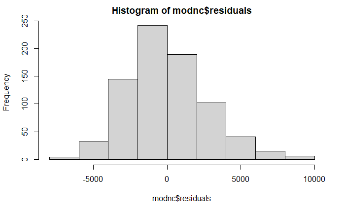

```r
hist(modnc$residuals)
```

20. Again suppose that you are interested in purchasing a car of this model that is four years old (in 2017) from North Carolina. How useful do you think that your model will be? What are some possible cons of using this model?

For a 4 year old car I would feel okay with this model. The linear regression line runs through about 4 years old at about the middle of the distribution of 4 year old cars in the plot below. I would prefer a more transformed model, perhaps the squre root model I used previously for texas. Both the transformed model and the lienar model run into eventually predicting a “free car”, which is a pretty big con of the data.

```r
summary(modnc)
```

```
Call:
lm(formula = Price ~ Age, data = MyCars2)

Residuals:
    Min      1Q  Median      3Q     Max
-6494.8 -1849.0  -297.4  1552.1  9575.5

Coefficients:
            Estimate Std. Error t value Pr(>|t|)
(Intercept) 21419.54     148.52  144.22   <2e-16 ***
Age         -1324.95      27.17  -48.76   <2e-16 ***
---
Signif. codes:  0 ‘***’ 0.001 ‘**’ 0.01 ‘*’ 0.05 ‘.’ 0.1 ‘ ’ 1

Residual standard error: 2720 on 774 degrees of freedom
Multiple R-squared:  0.7544,    Adjusted R-squared:  0.7541
F-statistic:  2378 on 1 and 774 DF,  p-value: < 2.2e-16
```

```r
confint(modnc, level = 0.90)
```

```
                  5 %      95 %
(Intercept) 21174.953 21664.124
Age         -1369.696 -1280.198
```

```r
newx.nc=data.frame(Age = 4)
head(newx.nc)
```

|  | Age |
| --- | --- |
| 1 | 4 |

```r
predict.lm(modnc, newx.nc, interval="confidence") # All peope; for poualtion
```

```
       fit      lwr      upr
1 16119.75 15927.98 16311.52
```

```r
predict.lm(modnc, newx.nc, interval="prediction") #For one perosn
```

```
       fit      lwr      upr
1 16119.75 10777.06 21462.44
```

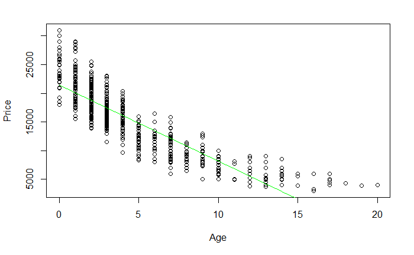

```r
B0.nc = summary(modnc)$coefficients[1,1] # Intercept
B1.nc = summary(modnc)$coefficients[2,1] # Slope

plot(Price~Age, MyCars2)
curve(B1.nc*x+B0.nc, col = "green", add=TRUE)
```